# Dæmaverkefni 2: Fyrri hluti

Markmið þessarar æfingar er að kynna ykkur fyrir myndrænni framsetningu í R með áherslu á framsetningu á talnabreytum. Þið notið skjalið *02_daemaverkefni_nem.Rmd* sem grunn, en þið finnið það á Canvas og vistið í verkefnamöppunni ykkar.

Ef þið hafið ekki sótt pakkana sem eru notaðir í þessu verkefni áður þá mun R vera til vandræða. Ein leið til að sækja pakka er að fara í valmyndina efst í RStudio og velja “Tools > Install Packages…” og slá nafnið á pakkanum eða pökkunum sem vantar í auða reitinn og smella á “Install”. Það þarf einungis að gera þetta einu sinni.

Munið að vista skjalið ykkar reglulega og vefa það saman annað slagið til að þið getið strax lagfært villur sem gætu komið upp.

# 1 Dæmi úr lesefni

Dæmin að neðan eru úr *Introduction to Modern Statistics* og vísa númerin hér að neðan í kaflanúmer og númer dæma í kafla í þeirri bók. Dæmin eru eftirfarandi:

- **Talnabreytur (vikur 5-6):** 5.2, 5.6, 5.10, 5.16 og 5.26

# 2 R-verkefni

## 2.1 Hlutfall kvenna á þjóðþingum heimsins

Innan stjórnmálafræðinnar eru ýmsar rannsóknir sem leitast við að svara spurningunni um hvers vegna hlutfall kvenna á þjóðþingum heimsins er breytilegt.[^1] Hvers vegna er það sums staðar undir 10%, víða á milli 20-30% og í nokkrum löndum yfir 40%?

Í þessum hluta ætlum að skoða tvo þætti sem rannsóknir benda til að gætu skipt máli: árið sem konur fengu kosningarétt í fyrsta sinn og tegund kosningakerfis. Við notum til þess gögn úr “World” gagnasafninu, en það inniheldur ýmsar upplýsingar um ríki heimsins (hver lína í gagnasafninu er eitt ríki). Þið getið opnað gögnin með því að [smella hér](https://docs.google.com/spreadsheets/d/1NHrryMUSOKjf4i4H8Qc1QOhqOBRdRUM3uFg39SL6Tm8/edit?usp=sharing). World fylgir mjög einföld kóðunarbók, sem inniheldur stutta lýsingu á öllum breytum í gagnasafninu. Hana er hægt að nálgast með því að [smella hér](https://docs.google.com/document/d/1zpEYPUWiqnJssQTXgwMitCfvKc45gdkHdc2WmTkryiM/edit?usp=sharing).

Í æfingunni munum við vinna með eftirtaldar breytur:

- *country*, auðkennisbreytuna fyrir lönd
- *ipu_wom13_all*, sem sýnir hlutfall kvenna á löggjafarþingum heimsins árið 2013 (þar sem eru tvær deildir á þingi, t.d. fulltrúadeild og öldungadeild, eru gögn fyrir neðri deild gefin upp). Upprunalegu gögnin eru fengin úr gagnasafni Alþjóðaþingmannasamtakanna (https://www.ipu.org/).
- *womyear*, sem sýnir árið sem konur fengu í fyrsta sinn kosningarétt. Upprunalegu gögnin eru fengin úr gagnasafni Alþjóðaþingmannasamtakanna (https://www.ipu.org/).
- *district_size3*, sem sýnir meðalfjölda þingsæta í kjördæmi. Breytan tekur eftirfarandi gildi:
  - “single member”: Lönd með meirihlutakosningakerfi með einmenningskjördæmum (t.d. Bandaríkin og Bretland)
  - “>1 to 5 members”: Lönd með hlutfallskosningakerfi með litlum kjördæmum (t.d. Írland og Sviss)
  - “6 or more members”: Lönd með hlutfallskosningakerfi með stórum kjördæmum (t.d. Holland og Ísland)
  - “NA”: Lönd þar sem gildi vantar (táknað NA í R, sem stendur fyrir “not available”). Vanalega síum við þessi gildi í burtu, svo þau sjáist ekki á gröfum.

$~$

### 2.1.1 Að hlaða gögnunum inn í minni

Byrjaðu á því að búa til nýjan kóðabút til að hlaða inn gögnunum og afrita eftirfarandi línur inn í kóðabútinn.

```r
gs4_deauth()
slod_a_gognin <- "https://docs.google.com/spreadsheets/d/1NHrryMUSOKjf4i4H8Qc1QOhqOBRdRUM3uFg39SL6Tm8/edit?usp=sharing"
world <- read_sheet(slod_a_gognin)
```

Við ætlum að stilla kóðabútinn þannig að við keyrum hann einungis einu sinni, en ekki í hvert sinn sem við vefum skjalið saman. Við gerum það með því að bæta inn stillingunni `cache=TRUE`. Myndin hér að neðan sýnir hvernig kóðabúturinn ætti að líta út, ásamt kóðabútunum sem koma á eftir. Athugið að vefslóðin er mjög löng og mun því flæða yfir á næstu línu í kóðanum ykkar. Ekki hafa áhyggjur af því þó línuskiptingin sé ekki nákvæmlega eins.

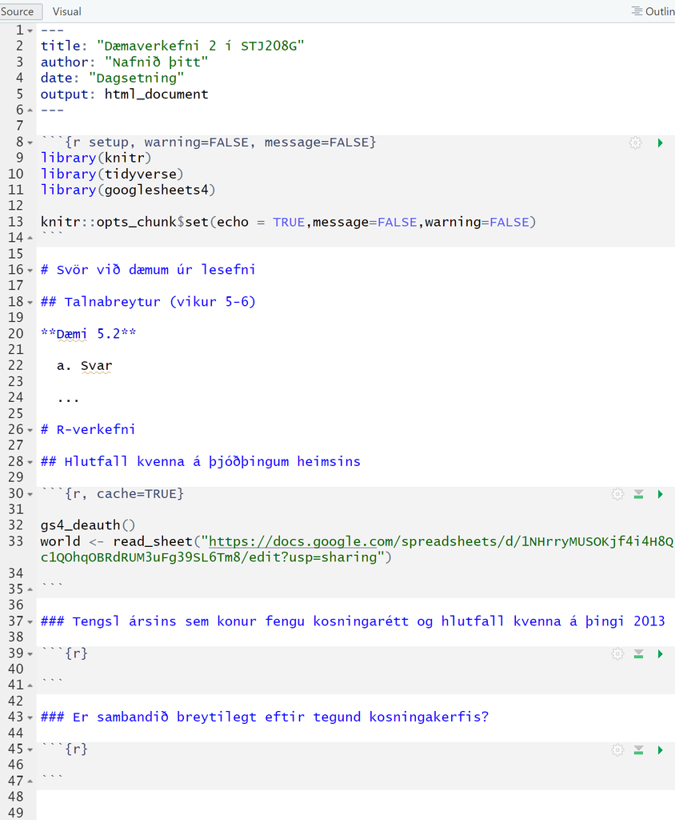

$~$

### 2.1.2 Tengsl ársins sem konur fengu kosningarétt og hlutfall kvenna á þingi 2013

Búðu nú til nýjan kafla og nýjan kóðabút fyrir fyrra grafið eins og sýnt er á myndinni að ofan (semsagt fyrir neðan kóðabútinn þar sem við hlöðum inn gögnunum). Búðu til punktarit þar sem árið sem konur fengu kosningarétt er á x-ásnum en hlutfall kvenna á þingi árið 2013 er á y-ásnum. Settu inn beina jöfnunarlínu á grafið sem er ekki með öryggisbili (`se=FALSE`). Þú getur horft á myndböndin um “GGPlot og Tidyverse-skipanir” og “Punktarit” til að koma þér af stað.

Settu inn merkingar á grafið. Titillinn ætti að vera: “Árið sem konur fengu kosningarétt og hlutfall kvenna á þingi 2013”. Merktu ásana með lýsandi texta á íslensku. Settu eftirfarandi `caption` undir myndina: “Gögn: Alþjóðaþingmannasamtökin (https://www.ipu.org/)”. Þú getur horft á myndbandið “Titill, nöfn á ásum og aðrar merkingar” til að hjálpa við þennan lið.

Vistaðu grafið með eftirfarandi nafni: *02_daemaverkefni_graf1.png*. Hafðu það 18 cm á breidd og 12 cm á hæð. Þú getur horft á myndbandið “Að vista graf” til að hjálpa við þennan lið.

**Hvernig er tengslunum á milli breytnanna háttað? Eru einhver tengsl? Ef það eru tengsl, eru þau jákvæð eða neikvæð? Hvað þýðir að tengslin séu jákvæð eða neikvæð í samhengi þessarar gagna? Svaraðu spurningunni fyrir neðan punktaritið (og utan við kóðabútinn).**

$~$

### 2.1.3 Er sambandið breytilegt eftir tegund kosningakerfis?

Búðu nú til nýjan kafla og nýjan kóðabút fyrir fyrra grafið eins og sýnt er á myndinni að ofan. Búðu til punktarit þar sem árið sem konur fengu kosningarétt er á x-ásnum en hlutfall kvenna á þingi árið 2013 er á y-ásnum. Nú skaltu stilla grafið þannig að punktarnir eru aðgreindir eftir tegund kosningakerfis (meðalfjölda þingsæta í kjördæmi). Settu inn beinar jöfnunarlínur á grafið sem eru ekki með öryggisbili (`se=FALSE`). Athugaðu að það ætti að vera jöfnunarlína fyrir hverja tegund kosningakerfis, ekki bara ein heildarlína. Þú getur horft á myndbandið “Að mappa breytur á graf” til að hjálpa við þennan lið.

Settu inn sömu merkingar og á fyrra grafinu, en bættu við eftirfarandi undirtitli: “Er sambandið breytilegt eftir tegund kosningakerfis?”. Merktu jafnframt skýrilykilinn fyrir tegund kosningakerfisins með eftirfarandi: “Tegund kosningakerfis”.

Síaðu (e. filter) í burtu gildi sem vantar af `district_size3` með því að setja viðeigandi línu af kóða í keðjuna af skipunum. Um þetta er lítillega fjallað í myndbandinu “Línurit”, en nánar verður fjallað um þetta í næsta skammti af sýnimyndböndum.

Nú skulum við færa skýrilykilinn neðst á grafið. Þú gerir það með því að bæta eftirfarandi línu af kóða neðst í rununa af kóða sem býr til grafið. Passaðu að línan á undan þarf að enda á plús.

```r
  theme(legend.position="bottom")
```

Vistaðu grafið með eftirfarandi nafni: *02_daemaverkefni_graf2.png*. Hafðu það 15 cm á breidd og 10 cm á hæð. Þú getur horft á myndbandið “Að vista graf” til að hjálpa við þennan lið.

Grafið ykkar ætti að líta svona út:

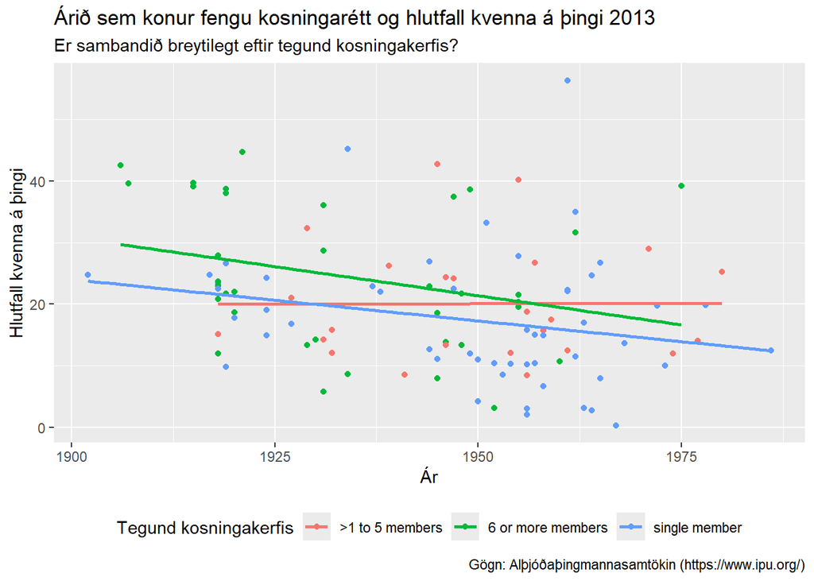

**Er sambandið á milli ársins sem konur fengu kosningarétt og hlutfall kvenna á þingi breytilegt eftir tegund kosningakerfis? Útskýrðu hvernig tengslunum er háttað. Svaraðu spurningunni fyrir neðan punktaritið (og utan við kóðabútinn).**

$~$

Þá erum við komin á leiðarenda að sinni. Í næstu viku bætist svo við seinni hluti dæmaverkefnisins. Þið þurfið því að bíða eftir honum áður en þið getið skilað þessu inn. Gangi ykkur vel!

[^1]: Sjá til dæmis í Wängnerud, L. (2009). Women in parliaments: Descriptive and substantive representation. *Annual Review of Political Science*, 12(1), 51-69.